# Assignment 2 - Integer Linear Programming

# 1 Problem 1

Consider the following ILP:

$$\begin{aligned}
&\max \quad 9 x_{1}+5 x_{2}+6 x_{3}+4 x_{4}\\
&\text { s.t. } \quad \\
&6 x_{1}+3 x_{2}+5 x_{3}+2 x_{4} \leq 10, \\
&x_{3}+x_{4} \leq 1,\\
&-x_{1}+x_{3} \leq 0,\\
&-x_{2}+x_{4} \leq 0\\
&x_{1}, x_{2}, x_{3}, x_{4} \in\{0,1\}
\end{aligned}$$

The following tree represents the solutions of all possible relaxations of the problem in which no sub-problem has been excluded (fathoming).

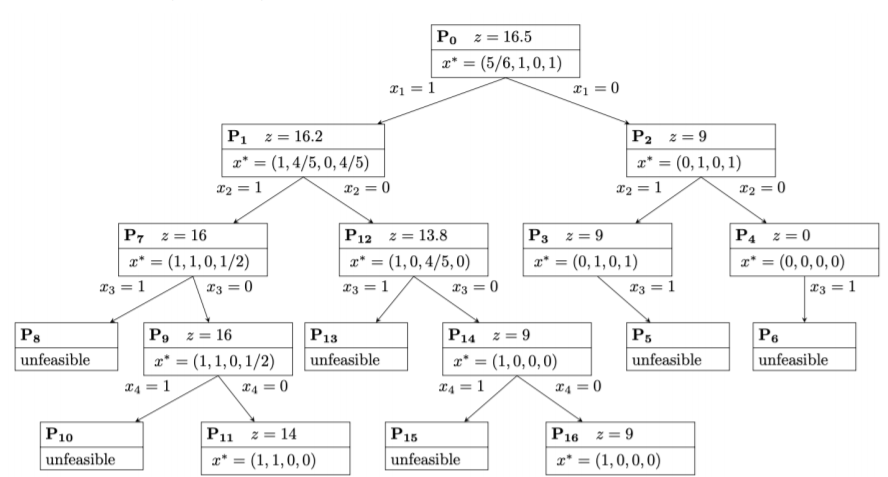

Suppose that the Branch and Bound (BB) algorithm applies to this problem. Also, let’s suppose that the algorithm visits the sub-problems in the following order P0 , P1 , . . . , P16. Clearly, the algorithm does not visit all nodes.

## 1.1 Esercizio 1

**Determine the nodes that will be visited by the BB algorithm and for each of them get the upper and lower limit deduced by the algorithm in the execution**

| Variabile | Valore |
| --- | --- |
| $x_1$ | 1 |
| $x_2$ | 1 |
| $x_3$ | 0 |
| $x_4$ | 0 |

Con un valore della funzione obiettivo pari a 14.

## 1.2 Esercizio 2

**Solve the problem with an ILP solver and check the value of the objective function matches the one found at point 1**

```r
library(lpSolveAPI)
library(dplyr)
library(pander)
library(tidyr)
```

Si definisce il problema come un problema di massimo e si definisce la funzione obiettivo.

```r
model <- make.lp(0, 4)
lp.control(model, sense = "max")
set.objfn(model, obj = c(9, 5, 6, 4))
```

Si introducono i vincoli all’interno del modello

```r
add.constraint(model,
               xt = c(6, 3, 5, 2),
               type = "<=",
               rhs = 10,
               indices = c(1, 2, 3, 4))
```

```r
add.constraint(model,
               xt = c(1,1 ),
               type = "<=",
               rhs = 1,
               indices = c(3, 4))
```

```r
add.constraint(model,
               xt = c(-1, 1),
               type = "<=",
               rhs = 0,
               indices = c(1,3))
```

```r
add.constraint(model,
               xt = c(-1, 1),
               type = "<=",
               rhs = 0,
               indices = c(2, 4))
```

Si impone che le variabili decisionali debbano essere binarie:

```r
set.type(model, c(1,2,3,4), "binary")
```

```r
model
```

```
## Model name:
##            C1   C2   C3   C4
## Maximize    9    5    6    4
## R1          6    3    5    2  <=  10
## R2          0    0    1    1  <=   1
## R3         -1    0    1    0  <=   0
## R4          0   -1    0    1  <=   0
## Kind      Std  Std  Std  Std
## Type      Int  Int  Int  Int
## Upper       1    1    1    1
## Lower       0    0    0    0
```

Il problema è stato costruito correttamente, quindi si procede a risolvere il problema di programmazione intera.

```r
solve(model)
```

```
## [1] 0
```

Si estrae il valore della funzione obiettivo, in corrispondenza della soluzione ottimale.

```r
get.objective(model)
```

```
## [1] 14
```

La funzione obiettivo ha un valore ottimale pari a 14

Si estrae ora il valore delle variabili decisonali in corrispondenza della soluzione ottimale.

```r
get.variables(model)
```

```
## [1] 1 1 0 0
```

In corrispondenza della soluzione ottimale si ha:

| Variabile | Valore |
| --- | --- |
| $x_1$ | 1 |
| $x_2$ | 1 |
| $x_3$ | 0 |
| $x_4$ | 0 |

Il valore della funzione obiettivo in corrispondenza della soluzione ottimale, coincide con quanto ricavato al punto precedente, così come coincidono i valori delle variabili decisionali.

# 2 Problem 2

SunNet is a residential Internet Service Provider (ISP) in the central Florida area. Presently, the company operates one centralized facility that all of its clients call into for Internet access.

To improve service, the company is planning to open three satellite offices in the cities of Pine Hills, Eustis, and Sanford. The company has identified five different regions to be serviced by these three offices. The following table summarizes the number of customers in each region, the service capacity at each office, and the monthly average cost per customer for providing the service to each region from each office. Table entries of “n.a.” indicate infeasible region-to-service center combinations.

SunNet would like to determine how many customers from each region to assign to each service center to minimize the total cost.

$$\begin{array}{lllll}
\text { Region } & \text { Pine Hills } & \text { Eustis } & \text { Sanford } & \text { Customers } \\
1 & \$ 6.50 & \$ 7.50 & \text { n.a. } & 30,000 \\
2 & \$ 7.00 & \$ 8.00 & \text { n.a. } & 40,000 \\
3 & \$ 8.25 & \$ 7.25 & \$ 6.75 & 25,000 \\
4 & \text { n.a. } & \$ 7.75 & \$ 7.00 & 35,000 \\
5 & \text { n.a. } & \$ 7.50 & \$ 6.75 & 33,000 \\
\hline
\text { Capacity } & 60,000 & 70,000 & 40,000 &
\end{array}$$

1. Draw a network flow model to represent this problem.
2. Implement your model and solve it.
3. What is the optimal solution?

## 2.1 Grafo del problema

Lo scopo del problema è assegnare i clienti delle 5 regioni, ai 3 nuovi uffici che la società vuole aprire, minimizzando il costo totale. Si tratta dunque di un problema di assegnamento rappresentato dal seguente grafo:

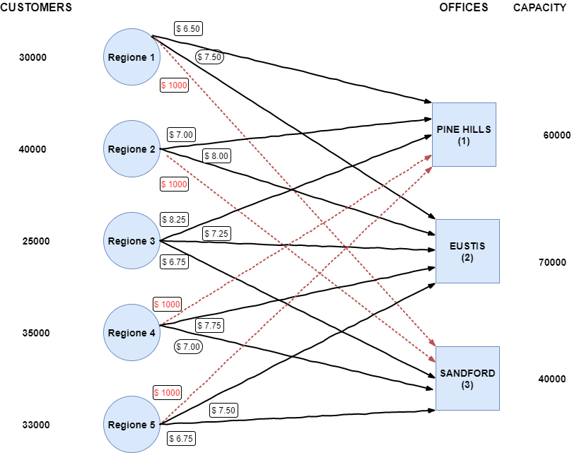

Di seguito si formalizza il problema.

## 2.2 Variabili decisionali

Lo scopo del problema è assegnare i clienti delle 5 regioni ad uno dei 3 nuovi uffici che la società desidera aprire, minimizzando il costo totale. Ogni combinazione regione-cliente, rappresenta una variabile decisionale $x_{i,j}$, dove $i=1,...,5$ rappresenta l’indice della regione, $j=1,...,3$, rappresenta l’indice dell’ufficio. Quindi le 15 variabili decisionali sono:

- $x_{1,1}$: numero di clienti della regione 1 assegnati all’ufficio di Pine Hills;
- $x_{1,2}$: numero di clienti della regione 1 assegnati all’ufficio di Eustis;
- $x_{1,3}$: numero di clienti della regione 1 assegnati all’ufficio di Sandford;
- $x_{2,1}$: numero di clienti della regione 2 assegnati all’ufficio di Pine Hills;
- $x_{2,2}$: numero di clienti della regione 2 assegnati all’ufficio di Eustis;
- $x_{2,3}$: numero di clienti della regione 2 assegnati all’ufficio di Sandford;
- $x_{3,1}$: numero di clienti della regione 3 assegnati all’ufficio di Pine Hills;
- $x_{3,2}$: numero di clienti della regione 3 assegnati all’ufficio di Eustis;
- $x_{3,3}$: numero di clienti della regione 3 assegnati all’ufficio di Sandford;
- $x_{4,1}$: numero di clienti della regione 4 assegnati all’ufficio di Pine Hills;
- $x_{4,2}$: numero di clienti della regione 4 assegnati all’ufficio di Eustis;
- $x_{4,3}$: numero di clienti della regione 4 assegnati all’ufficio di Sandford;
- $x_{5,1}$: numero di clienti della regione 5 asseganti all’ufficio di Pine Hills;
- $x_{5,2}$: numero di clienti della regione 5 asseganti all’ufficio di Eustis;
- $x_{5,3}$: numero di clienti della regione 5 assegnati all’ufficio di Sandford.

## 2.3 Funzione obiettivo

La funzione del problema, oggetto di minimizzazione è data dalla seguente combinazione lineare:

$$min\; 6.5x_{1,1} + 7.5x_{1,2} + 1000x_{1,3} + 7x_{2,1} + 8x_{2,2} + 1000x_{2,3} + 8.25x_{3,1}+7.25x_{3,2} + 6.75x_{3,3} + 1000x_{4,1}+7.75x_{4,2} + 7x_{4,3} + 1000x_{5,1} + 7.5x_{5,2} + 6.75x_{5,3}$$

## 2.4 Vincoli

Si definiscono i vincoli del problema:

### 2.4.1 Vincoli di capacità dei tre uffici

$$\left\{\begin{matrix}
\sum_{i = 1}^{5} x_{i, 1} \leq 60000 \\
\sum_{i = 1}^{5} x_{i, 2} \leq 70000 \\
\sum_{i = 1}^{5} x_{1,3} \leq 40000
\end{matrix}\right.$$

### 2.4.2 Supply constraints

$$\left\{\begin{matrix}
\sum_{j = 1}^{3} x_{1,j} = 30000 \\
\sum_{j = 1}^{3} x_{2, j} = 40000 \\
\sum_{j = 1}^3 x_{3, j} = 25000 \\
\sum_{j = 1}^{3} x_{4, j} = 35000 \\
\sum_{j = 1}^{3} x_{5, j} = 33000
\end{matrix}\right.$$

### 2.4.3 Vincolo di non negatività

$x_{i,j} \geq 0 \; per \; i=1,...5 \; j = 1,..,3$

### 2.4.4 Vincolo di interezza

Poichè le variabili decisionali rappresentano i clienti delle cinque regioni tra i tre uffici che la società è intenzionata ad aprire, si deve imporre che le variabili decisioanli siano intere.

$x_{i, j} \in N \; \forall i,j$

## 2.5 Implementazione del modello

Si definisce che il problema è di minimo e si introduce la funzione obiettivo, oggetto di minimizzazione.

```r
net.model <- make.lp(0, 15)
lp.control(net.model, sense = "min")
set.objfn(net.model, obj = c(6.5, 7.5, 1000,
                             7, 8, 1000,
                             8.25, 7.25, 6.75,
                             1000, 7.75, 7,
                             1000, 7.5, 6.75))
```

**Vincoli del problema**

Si introducono i vincoli di capacità

```r
add.constraint(net.model,
               xt = c(1,1,1,1,1),
               type = "<=",
               rhs = 60000,
               indices = c(1, 4, 7, 10, 13))
```

```r
add.constraint(net.model,
               xt = c(1,1,1,1,1),
               type ="<=",
               rhs = 70000,
               indices = c(2, 5, 8, 11, 14)
)
```

```r
add.constraint(net.model,
               xt = c(1,1,1,1,1),
               type = "<=",
               rhs = 40000,
               indices = c(3,6,9,12,15))
```

Si aggiungono i supply constraints

```r
add.constraint(net.model,
               xt = c(1,1,1),
               type = "=",
               rhs = 30000,
               indices = c(1,2,3))
```

```r
add.constraint(net.model,
               xt = c(1,1,1),
               type = "=",
               rhs = 40000,
               indices = c(4,5,6))
```

```r
add.constraint(net.model,
               xt = c(1,1,1),
               type = "=",
               rhs = 25000,
               indices = c(7,8,9))
```

```r
add.constraint(net.model,
               xt = c(1,1,1),
               type = "=",
               rhs = 35000,
               indices = c(10,11,12))
```

```r
add.constraint(net.model,
               xt = c(1,1,1),
               type = "=",
               rhs = 33000,
               indices = c(13, 14, 14))
```

Si introduce la non negatività delle variabili decisionali

```r
set.bounds(net.model, lower=c(rep(0, 15)))
```

Infine, si introduce la condizione di interezza delle variabili decisionali.

```r
set.type(net.model, c(seq(1, 15)), type = "integer")
```

## 2.6 Risoluzione del problema

```r
solve(net.model)
```

```
## [1] 0
```

Si estrae il valore ottimale della funzione obiettivo:

```r
get.objective(net.model)
```

```
## [1] 1156250
```

Il costo in corrispondenza della soluzione ottimale è pari 1156250$. Si estrae il valore delle variabili decisionali, in corrispondenza della soluzione ottimale.

```r
get.variables(net.model)
```

```
##  [1] 20000 10000     0 40000     0     0     0 20000  5000     0     0 35000
## [13]     0 33000     0
```

Il valore ottimale delle variabili decisionli, è riportao nella seguente tabella:

| Variabile | Valore |
| --- | --- |
| $x_{1,1}$ | 20000 |
| $x_{1,2}$ | 10000 |
| $x_{2,1}$ | 40000 |
| $x_{3,2}$ | 20000 |
| $x_{3,3}$ | 5000 |
| $x_{4,3}$ | 35000 |
| $x_{5,2}$ | 33000 |

Tutte le altre variabili decisionali, hanno un valore pari a zero in corrispondenza della soluzione ottimale.

Al fine di minimizzare il costo è necessario seguire la seguente regola:

- assegnare 20000 clienti della regione 1 all’ufficio di Pine Hills;
- assegnare 10000 clienti della regione 1 all’ufficio di Eustis;
- assegnare 40000 clienit della regione 2 all’ufficio di Pine Hills;
- assegnare 20000 clienti della regione 3 all’ufficio di Eustis;
- assegnare 5000 clienti della regione 3 all’ufficio di Sandford;
- assegnare 35000 clienti della regione 4 all’ufficio di Sandford;
- asseganre 33000 clienti della regione 5 all’ufficio di Eustis.

Notare come, le variabili decisionali $x_{1,3}$, $x_{2,3}$, $x_{4,1}$ e $x_{5,1}$, relative agli archi aggiunti artificialmente con un costo estremamente alto sono nulle, in coformità a quanto si voleva ottenere.